# Longevity of Contributions to the Open Source Video Game Modding Community

## By Davis Cook

### Definitions and Motivation

Within the video game community, mods (shorthand for modifications) are community made patches/changes/extensions to a video game. An example of a video game mod would be a change to the game's code that would add new weapons or armor to a fighting game, or add new levels to a puzzle game. The main distinguishing features of mods are that they are created through programming. For example, community made levels created in a level-editor provided by the game's developers would not be considered a video game mod. As such, since mods are created by programmers (often in conjunction with artists), many mods are part of the open source software community. This is not to say that all mods are made as open source software; there are many examples of closed source video game mods.

Despite open source mods not representing the entirety of the video game modding community, this analysis will be strictly focused on the subset of video game mods that are part of the open source community. Specifically the goal of this analysis is to look at the frequency of contributions over time to open source mods. There are two main components of this goal - the frequency over time of contributions by all authors and the frequency over time of contributions segregated on a per-author basis. This will provide insight into the longevity of open source modding projects and into the duration for which an individual contributor makes contributions to a project.

From this analysis the video game modding (modding is defined as the act of creating mods) community will have a better understanding of the longevity of projects and the issue of burn-out for individual mod contributors.

See (https://en.wikipedia.org/wiki/Mod_(video_gaming)) for further reading.

### 1. Table of Contents

1. Table of Contents
2. Data Collection Procedures
   1. Procedure
   2. Questions
   3. Collecting the Most Popular Video Games
      1. Required Libraries
   4. Filtering Out Competitive Multiplayer Games
   5. List of Games That Will be Examined
   6. Most Popular Mod for each of the Games
3. Data Collection Code
   1. API Calls
   2. Processing
4. Exploratory Data Analysis (EDA) and Hypothesis Testing
   1. Questions
   2. Project Size - Commit Count and Author Count
   3. Commits Per Author and Top Contributors
   4. Author Longevity
5. Conclusion

### 2. Data Collection Procedures

##### 2.A Procedure

In the open source software community, programmers must collaborate using some form of version control. There are many possible version control tools (git and apache subversion to name two major choices) that each open source software project may choose to use. As such, in data collection it is necessary to be aware of the many different version control tools that each project may use. Additionally, within each version control tool there are many more possible ways for the project to be hosted online in a way that the community can partake in it. Two main examples of hosting services for the git version control tool are Github and Gitlab. For the purposes of this analysis, only projects using the git version control tool that are hosted on Github will be examined. Naturally this raises the question of how may limiting the sample to only Github affect the results of the analysis. This choice could potentially bias the results on the longevity of certain projects because using one hosting platform versus another may give a project either more or less visibility within the community which could result in projects on some hosting platform either being systematically less or more likely to continue being worked on by members of the community. The differences between using different version control tools is less obvious how it may impact results. As such it certainly seems important that follow up analysis be performed that takes into account the large variety of version control tools and hosting platforms that exist. Nonetheless this analysis will proceed with only projects that are hosted on Github and made using the git version control tool.

The next important question is that of how the sample of open source video game mods will be choosen. It would be optimal to make a random sample in order to have the best results but unfortunately in this case a random sample is not feasible given the impossibility of enumerating all video games and then furthermore attempting to enumerate all the mods ever created for those video games. Without random sampling and also without wanting to bias the sample by hand-picking the video game mods, the sample will have to be generated in a procedural manner. For this analysis the procedure used to create the sample is as follows: take the top n most popular video games by player count and then select the most popular mod for each of those video games.

##### 2.B Questions

This procedure naturally raises many questions which will be now be addressed below:

1. If the video game is a competitive multiplayer game then it is by nature of being competitive, not designed to be modded. Some examples of popular competitive multiplayer games would be Dota 2 and Counter Strike: Global Offensive. In these games, any modifications would be discouraged (and often punished) by the developers because modifications would damage the competitive nature of the game. In the case of competitive multiplayer first person shooter games, a modification that would be deemed damaging to the competitive nature of the game would be a modification that gave the player more information about the positions of the enemies or other information that the player would not have in the game as it was provided by the developers. Of course one could argue that if the developers provided more information to the client than they wanted the player to be able to access they were using poor security practices - but that is not the focus of this analysis. Instead the importance of this issue is that for the purposes of this analysis any competitive multiplayer game will be skipped. This is because modifications to these games are not done in good faith and would be considered hacks and not part of the open source modding community that this analysis is for. Specifically this means that for the selection procedure, any time a competitive multiplayer game would be chosen, the next video game that is not a competitive multiplayer game will be chosen instead. Do note that this criteria does not exclude cooperative multiplayer games and games in which multiplayer is not the main focus. See (https://en.wikipedia.org/wiki/Cheating_in_video_games#Cheating_in_online_games) for further reading about mods in online games. Notice how the page doesn't even refer to mods - it simply calls them cheats!
2. If the most popular mod for a video game is not open source (as previously identified as a real possibility) then the next most popular mod for that video game that is open source will be chosen. See bullet point (4) for how this is accomplished.
3. The most popular video games by player count will be chosen by looking at the player count data provided by Steam (Steam is the most common DRM platform for video games and is used by the vast majority of the video-gaming community). Unfortunately due to the nature of Steam being a personal computer only video game platform the console (the xbox, playstation, etc... are consoles) modding community will be excluded. Again this decision could warrant further analysis in the future for examining any differences between the personal computer and console modding communities. Additionally there are some games for the personal computer that are not listed on Steam that will be left out of this analysis (for example Minecraft). For more information about Steam see (https://en.wikipedia.org/wiki/Steam_(software))
4. The most popular mod will be determined by a github search for the name of the video game sorted by most stars (where stars in this case are being used to indicate popularity of a mod). However, just picking the top result for this search could result in a poor sample because some projects that are related to a video game may not actually be a mod for the video game. For example, a top result could be a project designed to clone a video game. This would not be a mod but might show as the top result when searching for that video game. As such, some amount of discretion will have to be exercised when making the sample. In order to preserve the integrity of the sample, any cases in which this happens will be noted.
5. How does having the project data on Github for some open source video game mod project allow for determining data related to the longevity of the contributions to said project? Github provides the commit history of the project which gives the author and date of each contribution to the project. This is exactly the information we need.

##### 2.C Collecting the Most Popular Video Games

##### 2.C.a Required Libraries

1. Requests: python http request tool
2. NumPy: python scientific computing
3. Pandas: data frames
4. BeautifulSoup: web scraping utility
5. Matplotlib: plotting the data
6. scikit-learn: regression analysis

```python
import requests as requests
import numpy as np
import pandas as pd
from bs4 import BeautifulSoup
import re
import json
import matplotlib.pyplot as plt
from sklearn.linear_model import LinearRegression
from scipy.stats import ks_2samp
from dateutil.parser import parse

pd.options.display.max_columns = None
pd.options.display.max_rows = None
```

```python
url = "https://steamcharts.com/top/p."

frames = []
# grab the first 4 pages of results (page numbering starts at one)
for i in range(1, 5):
    text = requests.get(url + str(i)).text
    soup = BeautifulSoup(text)
    table = soup.find('table').prettify()
    frame = pd.read_html(table, flavor='bs4')[0]
    frames.append(frame)


games = []
for frame in frames:
    # each page in the webpage has 25 results
    for row in frame.itertuples():
        games.append(row[2])

for game in games:
    print(game)
```

```
PLAYERUNKNOWN'S BATTLEGROUNDS
Dota 2
Counter-Strike: Global Offensive
Tom Clancy's Rainbow Six Siege
Grand Theft Auto V
Path of Exile
Warframe
MONSTER HUNTER: WORLD
ARK: Survival Evolved
Rust
Team Fortress 2
Football Manager 2019
Ring of Elysium
Rocket League
Garry's Mod
Sid Meier's Civilization VI
Sid Meier's Civilization V
Euro Truck Simulator 2
Stellaris
Dead by Daylight
DayZ
Unturned
Paladins
Terraria
Farming Simulator 19
PAYDAY 2
Fallout 4
Total War: WARHAMMER II
Hearts of Iron IV
Europa Universalis IV
NBA 2K19
Football Manager 2018
Assassin's Creed Odyssey
Company of Heroes 2
The Witcher 3: Wild Hunt
War Thunder
Arma 3
Counter-Strike
Don't Starve Together
The Elder Scrolls Online
```

[output cut: 45 more lines]

```
The Crew 2
NBA 2K18
FINAL FANTASY XIV Online
PRO EVOLUTION SOCCER 2019
Don't Starve
Idle Champions of the Forgotten Realms
XCOM 2
太吾绘卷 The Scroll Of Taiwu
Kenshi
Warhammer: Vermintide 2
Grim Dawn
Subnautica
MapleStory 2
Crossout
Far Cry 5
```

##### 2.D Filtering Out Competitive Multiplayer Games

Now that the top 100 video games have been obtained: below is a mapping of each game to its status as a competitive multiplayer game. YES indicates that it is a competitive multiplayer game and will be filtered out. This was determined by reading the wikipedia article for each game in addition to its store page on steam.

**Click to show map**

* PLAYERUNKNOWN'S BATTLEGROUNDS -> YES * Dota 2 -> YES * Counter-Strike: Global Offensive -> YES * Tom Clancy's Rainbow Six Siege -> YES * Path of Exile -> YES * Grand Theft Auto V -> NO * Warframe -> YES * Team Fortress 2 -> YES * Rust -> YES * MONSTER HUNTER: WORLD -> NO * ARK: Survival Evolved -> NO * Football Manager 2019 -> NO * Ring of Elysium -> YES * Rocket League -> YES * Dead by Daylight -> NO * Sid Meier's Civilization V -> NO * Stellaris -> NO * Garry's Mod -> NO * Euro Truck Simulator 2 -> NO * Sid Meier's Civilization VI -> NO * Paladins -> YES * Farming Simulator 19 -> NO * Company of Heroes 2 -> YES * Unturned -> NO * Fallout 4 -> NO * Counter-Strike -> YES * NBA 2K19 -> NO * Total War: WARHAMMER II -> NO * Terraria -> NO * Football Manager 2018 -> NO * World of Tanks Blitz -> YES * Europa Universalis IV -> NO * Assassin's Creed Odyssey -> NO * Hearts of Iron IV -> NO * The Witcher 3: Wild Hunt -> NO * War Thunder -> YES * Arma 3 -> NO * The Elder Scrolls Online -> YES * Black Desert Online -> YES * PAYDAY 2 -> NO * Wallpaper Engine -> NOT a video game * Killing Floor 2 -> NO * 7 Days to Die -> NO * Artifact -> YES * Left 4 Dead 2 -> NO * The Elder Scrolls V: Skyrim Special Edition -> NO * Don't Starve Together -> NO * The Elder Scrolls V: Skyrim -> NO * Cities: Skylines -> NO * RimWorld -> NO * Age of Empires II: HD Edition -> NO * Spacewar -> NOT a video game (this one's complicated) * Brawlhalla -> YES * DARK SOULS™ III -> NO * The Forest -> NO * Black Squad -> YES * Slay the Spire -> NO * Stardew Valley -> NO * Human: Fall Flat -> NO * Mount & Blade: Warband -> NO * SMITE -> YES * Elite Dangerous -> YES * X4: Foundations -> NO * The Binding of Isaac: Rebirth -> NO * Tom Clancy's Ghost Recon® Wildlands -> NO * Yu-Gi-Oh! Duel Links -> YES * Divinity: Original Sin 2 -> NO * Crusader Kings II -> NO * VRChat -> Not a video game * Factorio -> NO * Borderlands 2 -> NO * Tom Clancy's The Division -> NO * Football Manager 2017 -> NO * Shadowverse -> YES * Dying Light -> NO * Counter-Strike: Source -> YES * Total War: ROME II - Emperor Edition -> NO * Insurgency: Sandstorm -> YES * Heroes & Generals -> YES * Idle Champions of the Forgotten Realms -> NO * Conan Exiles -> NO * PRO EVOLUTION SOCCER 2019 -> NO * FINAL FANTASY XIV Online -> YES * For Honor -> NO * MapleStory 2 -> YES * World of Warships -> YES * Crossout -> YES * Don't Starve -> NO * Warhammer: Vermintide 2 -> NO * NBA 2K18 -> NO * Kenshi -> NO * 太吾绘卷 The Scroll Of Taiwu -> NO * Russian Fishing 4 -> NO * XCOM 2 -> NO * Oxygen Not Included -> NO * Warface -> YES * No Man's Sky -> NO * TEKKEN 7 -> NO * Grim Dawn -> NO * Clicker Heroes -> NO

##### 2.E List of Games That Will be Examined

**Click to show list**

* Grand Theft Auto V * MONSTER HUNTER: WORLD * ARK: Surival Evolved * Football Manager 2019 * Dead by Daylight * Sid Meier's Civilization V * Stellaris * Garry's Mod * Euro Truck Simulator 2 * Sid Meier's Civilization VI * Farming Simulator 19 * Unturned * Fallout 4 * NBA 2K19 * Total War: WARHAMMER II * Terraria * Football Manager 2018 * Europa Universalis IV * Assassin's Creed Odyssey * Hearts of Iron IV * The Witcher 3: Wild Hunt * Arma 3 * PAYDAY 2 * Killing Floor 2 * 7 Days to Die * Left 4 Dead 2 * The Elder Scrolls V: Skyrim Special Edition * Don't Starve Together * The Elder Scrolls V: Skyrim * Cities: Skylines * RimWorld * Age of Empires II: HD Edition * DARK SOULS™ III * The Forest * Slay the Spire * Stardew Valley * Human: Fall Flat * Mount & Blade: Warband * X4: Foundations * The Binding of Isaac: Rebirth * Tom Clancy's Ghost Recon® Wildlands * Divinity: Original Sin 2 * Crusader Kings II * Factorio * Borderlands 2 * Tom Clancy's The Division * Football Manager 2017 * Dying Light * Total War: ROME II - Emperor Edition * Idle Champions of the Forgotten Realms * Conan Exiles * PRO EVOLUTION SOCCER 2019 * For Honor * Don't Starve * Warhammer: Vermintide 2 * NBA 2K18 * Kenshi * 太吾绘卷 The Scroll Of Taiwu * Russian Fishing 4 * XCOM 2 * Oxygen Not Included * No Man's Sky * TEKKEN 7 * Grim Dawn * Clicker Heroes

##### 2.F Most Popular Mod for each of the Games

**Click to show list**

* Grand Theft Auto V -> https://github.com/crosire/scripthookvdotnet * MONSTER HUNTER: WORLD -> https://github.com/danong/mhw-dps-overlay ; most starred project (https://github.com/LartTyler/MHWDB-Docs) was a website * ARK: Surival Evolved -> https://github.com/FezVrasta/ark-server-tools * Football Manager 2019 -> no mods * Dead by Daylight -> https://github.com/BlackFurniture/dbdlobby * Sid Meier's Civilization V -> https://github.com/Thalassicus/cep-bnw (note searched "civ v" instead of full game name) * Stellaris -> https://github.com/cloudwu/stellaris_cn * Garry's Mod -> https://github.com/wiremod/wire * Euro Truck Simulator 2 -> https://github.com/nlhans/ets2-sdk-plugin * Sid Meier's Civilization VI -> https://github.com/Gedemon/Civ6-YnAMP (note searched "civ vi" instead of full game name) * Farming Simulator 19 -> https://github.com/napalm00/FS19PlaceAnywhere * Unturned -> https://github.com/RocketMod/Rocket.Unturned * Fallout 4 -> https://github.com/RobCoIndustries/pipboylib * NBA 2K19 -> no mods * Total War: WARHAMMER II -> https://github.com/mklabs/npfm * Terraria -> https://github.com/Pryaxis/TShock * Football Manager 2018 -> no mods * Europa Universalis IV -> https://github.com/matanki-saito/EU4dll * Assassin's Creed Odyssey -> no mods * Hearts of Iron IV -> https://github.com/Wolferos/Hearts-of-Iron-IV-The-Great-War * The Witcher 3: Wild Hunt -> https://github.com/Traderain/Wolven-kit * Arma 3 -> https://github.com/acemod/ACE3 * PAYDAY 2 -> https://github.com/Kamikaze94/WolfHUD * Killing Floor 2 -> https://github.com/notblackout/kf2-controlled-difficulty * 7 Days to Die -> https://github.com/dmustanger/7dtd-ServerTools * Left 4 Dead 2 -> https://github.com/Tabbernaut/L4D2-Plugins * The Elder Scrolls V: Skyrim Special Edition -> https://github.com/loot/loot (note searched "skyrim" instead of full name) * Don't Starve Together -> https://github.com/fairplay-zone/docker-dontstarvetogether * The Elder Scrolls V: Skyrim -> (note ignoring this since it's the same game as the special addition above) * Cities: Skylines -> https://github.com/DominicMaas/Tango * RimWorld -> https://github.com/skyarkhangel/Hardcore-SK * Age of Empires II: HD Edition -> https://github.com/IamFlea/bartender ; top 3 starred were not mods (https://github.com/SFTtech/openage) (https://github.com/peterolson/AOE2-Real-Map-Creator) (https://github.com/mullikine/aokts) * DARK SOULS™ III -> https://github.com/Kaldaien/SoulsUnsqueezed ; top starred was a guide (https://github.com/igromanru/Dark-Souls-III-Cheat-Engine-Guide) and next top starred was a data packing tool (https://github.com/Atvaark/BinderTool * The Forest -> https://github.com/FluffyFishGames/ModAPI-The-Forest-Mods (note had to search for "the forest" instead of the forest without quotes because without quotes everything is forest data structure stuff) ; the top starred were not related to the video game * Slay the Spire -> https://github.com/kiooeht/ModTheSpire * Stardew Valley -> https://github.com/Pathoschild/SMAPI * Human: Fall Flat -> https://github.com/Stektpotet/HFF-Util * Mount & Blade: Warband -> https://github.com/mbw-economy/Economy-Mod-for-Mount-and-Blade--Warband * X4: Foundations -> https://github.com/ParadoxForge/X4Foundations-SaveBugFixer * The Binding of Isaac: Rebirth -> https://github.com/Hyphen-ated/RebirthItemTracker * Tom Clancy's Ghost Recon® Wildlands -> no mods * Divinity: Original Sin 2 -> https://github.com/krisives/divinityfourplayer * Crusader Kings II -> https://github.com/Ofaloaf/postapoc * Factorio -> https://github.com/wube/factorio-data ; first project was not related to the video game * Borderlands 2 -> https://github.com/gibbed/Gibbed.Borderlands2 * Tom Clancy's The Division -> no mods * Football Manager 2017 -> no mods * Dying Light -> https://github.com/ThirteenAG/DyingLight.BorderlessWindowedMode * Total War: ROME II - Emperor Edition -> no mods * Idle Champions of the Forgotten Realms -> https://github.com/raekuul/IdleDragons-ahk-Scripts * Conan Exiles -> https://github.com/A15Bog/conanexilessql * PRO EVOLUTION SOCCER 2019 -> https://github.com/pes-modding/sider5 * For Honor -> no mods * Don't Starve -> https://github.com/paintdream/DontStarveLuaJIT * Warhammer: Vermintide 2 -> https://github.com/millionart/Vermintide-2-Controller-Tweaker * NBA 2K18 -> no mods * Kenshi -> https://github.com/f03n1x/kenshiMap * 太吾绘卷 The Scroll Of Taiwu -> no mods * Russian Fishing 4 -> no mods * XCOM 2 -> https://github.com/BlueRaja/XCom2Mods * Oxygen Not Included -> https://github.com/javisar/ONI-Modloader-Mods * No Man's Sky -> https://github.com/Ant2888/NMSExtender * TEKKEN 7 -> https://github.com/roguelike2d/TekkenBot * Grim Dawn -> https://github.com/Lasse-B/GD-CPU-Affinity * Clicker Heroes -> https://github.com/swiftb/clicker-heroes-sw1ft-bot

The sample selection process was fairly involved but with the sample created, the rest of the data collection process is quick because of the Github API that will easily allow for accessing the necessary data. All that will be left is to put the data into the appropriate dataframes. Take a look at https://developer.github.com/v3/) the Github API developer documentation for further reading about how to access the data set used for this analysis. Additionally the API docs contains information that would be useful for performing further or additional analysis of Github contribution data.

### 3. Data Collection Code

##### 3.A API Calls

```python
mod_urls = [
    "https://github.com/crosire/scripthookvdotnet",
    "https://github.com/danong/mhw-dps-overlay",
    "https://github.com/FezVrasta/ark-server-tools",
    "https://github.com/BlackFurniture/dbdlobby",
    "https://github.com/Thalassicus/cep-bnw",
    "https://github.com/cloudwu/stellaris_cn",
    "https://github.com/wiremod/wire",
    "https://github.com/nlhans/ets2-sdk-plugin",
    "https://github.com/Gedemon/Civ6-YnAMP",
    "https://github.com/napalm00/FS19PlaceAnywhere",
    "https://github.com/RocketMod/Rocket.Unturned",
    "https://github.com/RobCoIndustries/pipboylib",
    "https://github.com/mklabs/npfm",
    "https://github.com/Pryaxis/TShock",
    "https://github.com/matanki-saito/EU4dll",
    "https://github.com/Wolferos/Hearts-of-Iron-IV-The-Great-War",
    "https://github.com/Traderain/Wolven-kit",
    "https://github.com/acemod/ACE3",
    "https://github.com/Kamikaze94/WolfHUD",
    "https://github.com/notblackout/kf2-controlled-difficulty",
    "https://github.com/dmustanger/7dtd-ServerTools",
    "https://github.com/Tabbernaut/L4D2-Plugins",
    "https://github.com/loot/loot",
    "https://github.com/fairplay-zone/docker-dontstarvetogether",
    "https://github.com/DominicMaas/Tango",
    "https://github.com/skyarkhangel/Hardcore-SK",
    "https://github.com/IamFlea/bartender",
    "https://github.com/Kaldaien/SoulsUnsqueezed",
    "https://github.com/FluffyFishGames/ModAPI-The-Forest-Mods",
    "https://github.com/kiooeht/ModTheSpire",
    "https://github.com/Pathoschild/SMAPI",
    "https://github.com/Stektpotet/HFF-Util",
    "https://github.com/mbw-economy/Economy-Mod-for-Mount-and-Blade--Warband",
    "https://github.com/ParadoxForge/X4Foundations-SaveBugFixer",
    "https://github.com/Hyphen-ated/RebirthItemTracker",
    "https://github.com/krisives/divinityfourplayer",
    "https://github.com/Ofaloaf/postapoc",
    "https://github.com/wube/factorio-data",
    "https://github.com/gibbed/Gibbed.Borderlands2",
    "https://github.com/ThirteenAG/DyingLight.BorderlessWindowedMode",
    "https://github.com/raekuul/IdleDragons-ahk-Scripts",
    "https://github.com/A15Bog/conanexilessql",
    "https://github.com/pes-modding/sider5",
    "https://github.com/paintdream/DontStarveLuaJIT",
    "https://github.com/millionart/Vermintide-2-Controller-Tweaker",
    "https://github.com/f03n1x/kenshiMap",
    "https://github.com/BlueRaja/XCom2Mods",
    "https://github.com/javisar/ONI-Modloader-Mods",
    "https://github.com/Ant2888/NMSExtender",
    "https://github.com/roguelike2d/TekkenBot",
    "https://github.com/Lasse-B/GD-CPU-Affinity",
    "https://github.com/swiftb/clicker-heroes-sw1ft-bot"
]

# transform the project urls to the api url
mod_api_urls = []
for url in mod_urls:
    api_url = url.replace("https://github.com", "https://api.github.com/repos");
    api_url += "/commits?page=1&per_page=100"
    mod_api_urls.append(api_url)

def parse_response(response, commits):
    json = response.json()
    for commit in json:
        author = commit['commit']['author']['name']
        time = commit['commit']['author']['date']
        commits.append({
            'author': author,
            'time': time
        })

response_map = {}

def build_frame(url):
    # responses are paginated so we must use a loop to grab all the commits
    # in a repository
    commits = []
    responses = []
    response = requests.get(url,
        headers={
            'Authorization': 'token cf03b7f35424a08f30bfcce1619c9219f4a3942b'
        })
    responses.append(response)
    parse_response(response, commits)
    # only need to do pagination code if the project has more than 100 commits
    if ('last' in response.links):
        last_url = response.links['last']['url']
        # this regex gets the last page number
        page_number = re.search(r'page=(\d+).*$', last_url).group(1)
        for i in range(2, int(page_number) + 1):
            next_url = response.links['next']['url']
            response = requests.get(next_url,
                headers={
                    'Authorization': 'token cf03b7f35424a08f30bfcce1619c9219f4a3942b'
                })
            responses.append(response)
            parse_response(response, commits)
    response_map[url] = {
        'commits': commits,
        'responses': responses
    }


# due to github api rate limits we can only make 5000 requests per hour
# and at 100 commmits per request this limits us to getting 500,000 commits
# which should be more than enough however since this is a long operation
# this code should really only be executed once which is why it stores
# all of the response data so further processing can be performed as necessary
# in a different code block
for mod_api_url in mod_api_urls:
    build_frame(mod_api_url)
```

##### 3.B Processing

```python
# now convert the python dicts to pandas data frames
# one giant data frame will be created with 3 columns/attributes
# project - commit author - commit time

# from this dataframe it will be possible to perform all
# the analysis that will be done
frame = pd.DataFrame(columns=['project', 'author', 'time'])

for url in response_map:
    response = response_map[url]
    commits = response['commits']
    for commit in commits:
        frame = frame.append({
            'project': url,
            'author': commit['author'],
            'time': commit['time']
        }, ignore_index=True)

print('computed dataframe')
print(frame.head())
```

```
computed dataframe
                                             project            author  \
0  https://api.github.com/repos/crosire/scripthoo...           crosire
1  https://api.github.com/repos/crosire/scripthoo...  Frederik Bolding
2  https://api.github.com/repos/crosire/scripthoo...           crosire
3  https://api.github.com/repos/crosire/scripthoo...  Frederik Bolding
4  https://api.github.com/repos/crosire/scripthoo...  Frederik Bolding

                   time
0  2018-10-05T18:24:17Z
1  2018-10-03T16:19:25Z
2  2018-10-02T15:48:58Z
3  2018-10-01T05:32:44Z
4  2018-10-01T05:29:58Z
```

### 4. Exploratory Data Analysis (EDA) and Hypothesis Testing

With the data collection completed, an investigation into the data can begin. A list of questions that this EDA will attempt to answer is below:

##### 4.A Questions

1. How does the size of a project (measured in number of commits) relate to the number of contributors to the project? As a hypothesis it would make sense that projects with larger numbers of contributors would have more commits but there may be outliers in which a project with many commits is made only by a small number of contributors or the opposite. This information may be useful because it could help to establish the notion that growing open source video mods could best be done by getting more developers interested in the projects.
2. What percentage of the total commits in a project are made by the author with the most commits, the second most commits, etc...? This question will look to see if one or two core authors of a project perform the majority of the work or if the contributions to an open source mod are more evenly split among the contributors. Note that the main reason to use commits as an indication of contributions instead of lines of code is because many activities like installing a new dependency or reformatting may involve changing many many lines of code that would not be representative of the work involved. This can be examined overall accross all projects or in relation to the size of a project.
3. What is the length of time for which a contributor works on a project? This would be defined as the time difference between the time for which an individual author's first commit appears in the commit history and the time for which an individual's last commit appears in the commit history. This duration can be examined overall for all the projects, on a per project basis, and most interestingly in relation to the number of commits/percentage of project commits made by that author.
4. Is there some trend or pattern in the length of time that an author will work on a project? Is there some way to predict the time at which an author will stop making new contributions to a project given their previous commit history? This could be examined by making a histogram of commit frequency over time periods and determining of there exists some general shape to that graph that could be used to predict at which point commit frequency would go to zero.

The hypothesis testing is interspersed with the EDA where appropriate. Mostly this means that after EDA has revealed some interesting correlation or relationship there is a follow up hypothesis test performed immediately afterwards to determine the significance of the finding.

###### 4.B Project Size - Commit Count and Author Count

```
Text(0.5,1,'Relationship between number of authors and number of commits in a project')
```

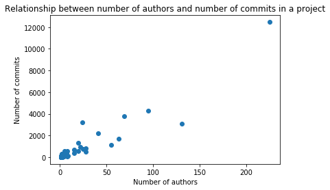

```python
value_map = {}
for tuple in frame.itertuples():
    if tuple.project not in value_map:
        value_map[tuple.project] = {
            'commit_count': 0,
            'authors': []
        }
    value_map[tuple.project]['commit_count'] += 1
    if tuple.author not in value_map[tuple.project]['authors']:
        value_map[tuple.project]['authors'].append(tuple.author)

x = []
y = []
for project in value_map:
    x.append(len(value_map[project]['authors']))
    y.append(value_map[project]['commit_count'])

plt.scatter(x, y)
plt.gca().set_xlabel('Number of authors')
plt.gca().set_ylabel('Number of commits')
plt.title('Relationship between number of authors and number of commits in a project')
```

This seems to indicate a very clear positive correlation between number of commits and number of authors. However it does have one outlier at almost 250 authors and 13000 commits. What does the plot look like if we remove that one outlier. Does the trend still seem as clear? Additionally there are many many projects clustered close to the bottom left of the graph such that they are too close together to easily separate. An additional graph that only plots the subset of projects that have less than 1000 commits may make the data for that region clearer.

```
Text(0.5,1,'Relationship between number of authors and number of commits in a project (# of commits <= 1000)')
```

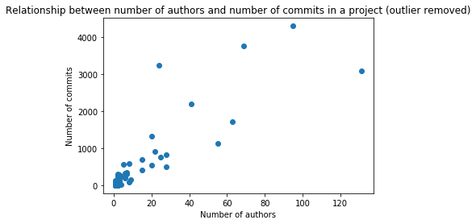

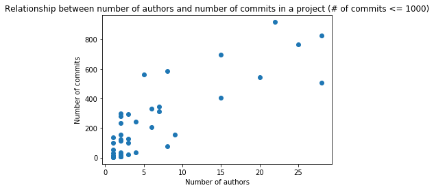

```python
outlier = "https://api.github.com/repos/acemod/ACE3/commits?page=1&per_page=100"

x = []
y = []
for project in value_map:
    if project != outlier:
        x.append(len(value_map[project]['authors']))
        y.append(value_map[project]['commit_count'])

plt.scatter(x, y)
plt.gca().set_xlabel('Number of authors')
plt.gca().set_ylabel('Number of commits')
plt.title('Relationship between number of authors and number of commits in a project (outlier removed)')

outlier = "https://api.github.com/repos/acemod/ACE3/commits?page=1&per_page=100"

x = []
y = []
for project in value_map:
    if value_map[project]['commit_count'] <= 1000:
        x.append(len(value_map[project]['authors']))
        y.append(value_map[project]['commit_count'])

plt.figure()
plt.scatter(x, y)
plt.gca().set_xlabel('Number of authors')
plt.gca().set_ylabel('Number of commits')
plt.title('Relationship between number of authors and number of commits in a project (# of commits <= 1000)')
```

With the outlier removed the trend is less clear but still persists. The same is true for the case where number of commits is less than or equal to 1000. Next linear regression will be performed in order to determine the strength of the correlation and to create a predictive model.

```
r^2 computation for the dataset with the outlier removed = 0.738945063677
prediction equation is commits_hat = 33.3868911207 * authors + 99.8152128855
r^2 computation for the dataset with only projects that have 1000 or less commits = 0.702461617403
prediction equation is commits_hat = 27.5678463555 * authors + 57.0617769419
```

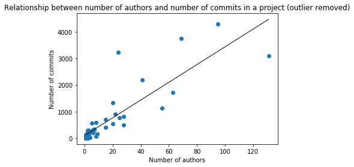

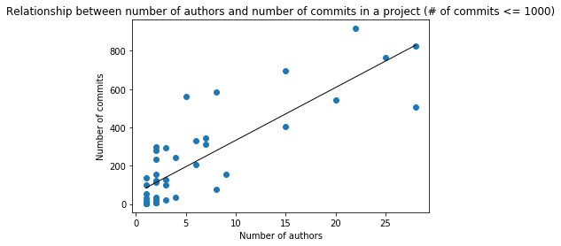

```python
outlier = "https://api.github.com/repos/acemod/ACE3/commits?page=1&per_page=100"

x = []
y = []
for project in value_map:
    if project != outlier:
        x.append(len(value_map[project]['authors']))
        y.append(value_map[project]['commit_count'])

fit = np.polyfit(x,y,1)
fit_fn = np.poly1d(fit)

x_min = np.min(x)
x_max = np.max(x)
y_min = fit_fn(x_min)
y_max = fit_fn(x_max)

plt.scatter(x, y)
plt.plot([x_min, x_max], [y_min, y_max], color='k', linestyle='-', linewidth=1)
plt.gca().set_xlabel('Number of authors')
plt.gca().set_ylabel('Number of commits')
plt.title('Relationship between number of authors and number of commits in a project (outlier removed)')

# r^2 computation
x_np = np.array(x)
reg = LinearRegression().fit(x_np.reshape(-1, 1), y)
score = reg.score(x_np.reshape(-1, 1), y)
print('r^2 computation for the dataset with the outlier removed = ' + str(score))
print('prediction equation is commits_hat = ' + str(reg.coef_[0]) + ' * authors + ' + str(reg.intercept_))

x_1 = []
y_1 = []
for project in value_map:
    if value_map[project]['commit_count'] <= 1000:
        x_1.append(len(value_map[project]['authors']))
        y_1.append(value_map[project]['commit_count'])

fit_1 = np.polyfit(x_1,y_1,1)
fit_fn_1 = np.poly1d(fit_1)

x_min_1 = np.min(x_1)
x_max_1 = np.max(x_1)
y_min_1 = fit_fn_1(x_min_1)
y_max_1 = fit_fn_1(x_max_1)

plt.figure()
plt.scatter(x_1, y_1)
plt.plot([x_min_1, x_max_1], [y_min_1, y_max_1], color='k', linestyle='-', linewidth=1)
plt.gca().set_xlabel('Number of authors')
plt.gca().set_ylabel('Number of commits')
plt.title('Relationship between number of authors and number of commits in a project (# of commits <= 1000)')

# r^2 computation
x_np_1 = np.array(x_1)
reg_1 = LinearRegression().fit(x_np_1.reshape(-1, 1), y_1)
score_1 = reg_1.score(x_np_1.reshape(-1, 1), y_1)
print('r^2 computation for the dataset with only projects that have 1000 or less commits = ' + str(score_1))
print('prediction equation is commits_hat = ' + str(reg_1.coef_[0]) + ' * authors + ' + str(reg_1.intercept_))
```

The graph with the outlier removed had an r^2 score of 0.739, meanining that 73.9 percent of the variance in the # of commits can be predicted by the # of authors for a project. For the graph with only projects with a # of commits less than or equal to 1000 the r^2 score is 0.703, meaning that 70.3 percent of the variance in the # of commits can be predited by the # of authors for a project. With r^2 scores around 0.7, there is a clear positive correlation between the two variables. But because 0.7 is still far from 1.0 this means that the number of authors alone is insufficient to completely predict the number of commits on a project.

Nonetheless this analysis confirm the prediction that projects with more authors would certainly have more commits. This does not establish whether having more authors causes more commits or having more commits causes more authors but since authors create commits it seems clear that at least to a degree having more authors would cause more commits to be created. But the opposite idea, where having more commits makes a project more likely to attract new developers cannot be ruled out.

Some intriguing results of this analysis are that according to the graphs, all projects with only 1 author have less than 200 commits, meaning that any project with more than 200 commits would have more than 1 author. This would seem to indicate that at a certain point once a project has had some amount of development put towards it (>= 200 commits) it begins to attract attention from other mod developers in the community who also begin to make contributions towards the project.

##### 4.C Commits Per Author and Top Contributors

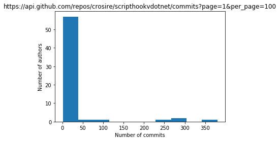

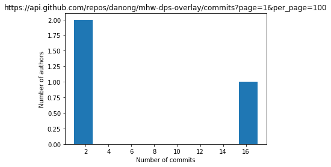

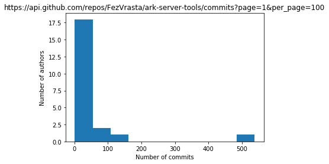

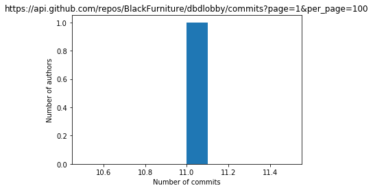

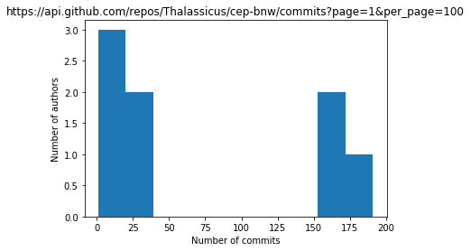

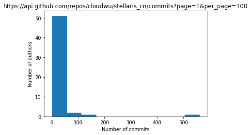

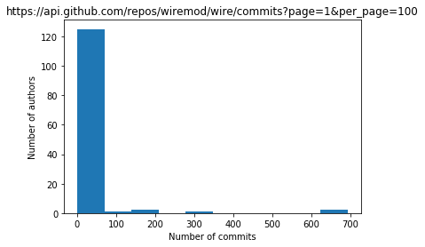

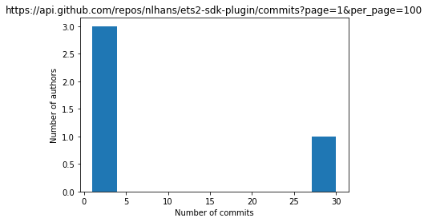

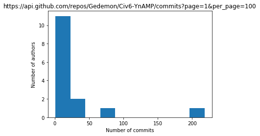

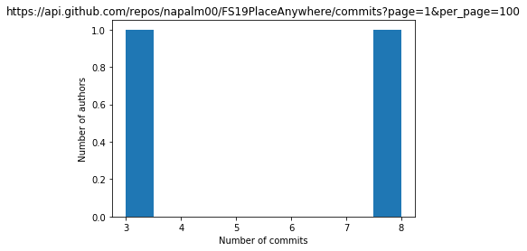

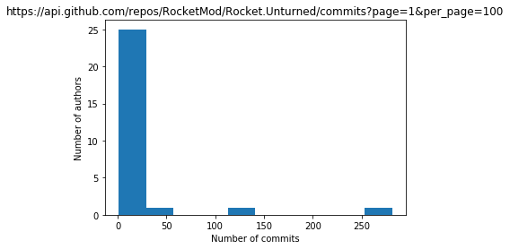

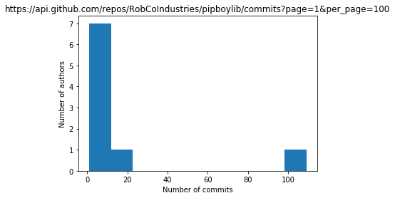

[40 more figures not shown]

```python
# for each project compute the number of commits made per author
# first graph this information on a per-project basis
# this will create > 50 graphs to look at which may provide a good visual overview
# of any trends
# from this visualization, an appropriate overall visualization can be made

commit_map = {}
for tuple in frame.itertuples():
    if tuple.project not in commit_map:
        commit_map[tuple.project] = {}
    if tuple.author not in commit_map[tuple.project]:
        commit_map[tuple.project][tuple.author] = 0
    commit_map[tuple.project][tuple.author] += 1

for project in commit_map:
    author_counts = []
    for author in commit_map[project]:
        author_counts.append(commit_map[project][author])
    plt.figure()
    plt.hist(author_counts)
    plt.gca().set_xlabel('Number of commits')
    plt.gca().set_ylabel('Number of authors')
    plt.title(project)
```

The above graphs created to the distribution of number of commits fall into three discintion categories:

1. right-skewed
2. bimodal
3. unimodal

Two good examples right-skewed graphs are the graphs for the https://github.com/crosire/scripthookvdotnet project and the https://github.com/Ofaloaf/postapoc project. In these graphs there are many many authors with a small number of commits and there are a few authors with many, many commits that make up the right tail of the distribution. This type of distribution seems to indicate a project in which there is a small number of core contributors that create the majority of the commits in the project and many additional contributors that each write a few commits each.

An example of a bimodal graph is the graph for the https://github.com/swiftb/clicker-heroes/sw1ft-bit project and the https://github.com/wube/factorio-data project. However calling these graphs bimodal is a bit disingenuous. In reality the reason for these graphs being bimodal is that there are some number of authors with a really small number of commits and one singular author with a large number of commits. These projects would easily fall under the umbrella of the right-skewed graphs if instead of having only one author with a large number of commits, they had multiple authors with a large number of commits. So in truth it seems that these graphs still demonstrate the same relationship as the right-skewed graph - there is still a small number of core contributors that make most of the commits and many contributors that make a few commits each.

A good example of the unimodal graph is the graph for https://gitub.com/pes-modding/sider5 project. However calling this graph and the others like it biomal is a bit disingenuous. The unimodal graphs are only the graphs for which there is only one author which makes them de-facto unimoal distributions since it's only a distribution of a single data point. In these projects there is a still a small number of core contributors that make most of the commits but in these specific projects there are no contributors that make a small number of commits. Perhaps in these cases it is because the project has not yet become large enough to get the attention of other mod developers that would want to contribute code into the mod (this can be said because from previously analysis it is known that the projects with only one author all have a total number of commits that is very small - less than 200).

So the overall information that can be taken from these graphs is that the contributions to an open source video game mod seem to follow a right-skewed distribution.

```
Text(0.5,1,'Overall commit per author distribution across all projects')
```

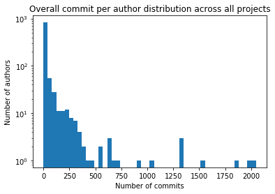

```python
# create an overall histogram
author_counts = []
for project in commit_map:
    for author in commit_map[project]:
        author_counts.append(commit_map[project][author])

plt.hist(author_counts, 50)
plt.yscale('log')
plt.gca().set_xlabel('Number of commits')
plt.gca().set_ylabel('Number of authors')
plt.title('Overall commit per author distribution across all projects')
```

An overall histogram for showing the number of commits per author distributed across all projects probably isn't a particularly accurate graph since the fact that some projects will have larger commit numbers that other due to the project will help to right-skew the graph more than it probably should be. But if that issue is ignored this graph does show that the number of commit distribution truly is definitely right-skewed.

```
Text(0.5,1,'Distribution of average percentage of commits made by each contributor by project')
```

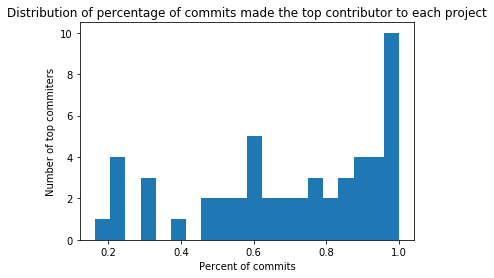

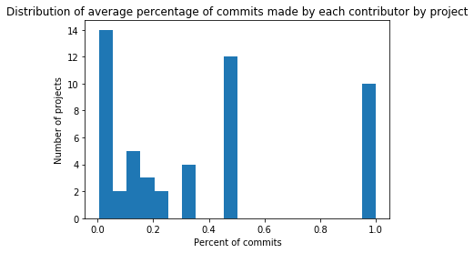

```python
# now rather than looking at the distribution of commits looking at
# the percentage of commits will allow for normalizing the commit data
# across projects so overall information can be better created

# determine the percentage of commits created by the author with the most commits
# then determine what percentage of commits would be created by each author if
# each author made the same number of commits, i.e. the average commit percentage
# which is just number 100 percent divided by the number of authors
top_percent = []
average_percent = []
for project in commit_map:
    max_count = 0
    total_count = 0
    for author in commit_map[project]:
        if commit_map[project][author] > max_count:
            max_count = commit_map[project][author]
        total_count += commit_map[project][author]
    top_percent.append(max_count / total_count)
    average_percent.append(1 / len(commit_map[project].keys()))

plt.hist(top_percent, 20)
plt.gca().set_xlabel('Percent of commits')
plt.gca().set_ylabel('Number of top commiters')
plt.title('Distribution of percentage of commits made the top contributor to each project')

plt.figure()
plt.hist(average_percent, 20)
plt.gca().set_xlabel('Percent of commits')
plt.gca().set_ylabel('Number of projects')
plt.title('Distribution of average percentage of commits made by each contributor by project')
```

The above graphs show two distrubtions: the first graph being the distribution of the percentage of the total number of commits in a project contributed by the one author with the largest number of commits, and the second graph being the distribution of the percentage of commits contributed on average by each author to the same projects. This allows for a comparison between the work done by the author with the largest number of commits and the average work done per commiter. This can be done with a two-sample KS test. Despite the two histograms above being categorical data, the underlying data is qualitative which means that the two-sample KS test can be used. The two-sample KS test determines if two distributions are statistically different.

```python
result = ks_2samp(top_percent, average_percent)
print("p value for two-sample KS test is = " + str(result.pvalue))
```

```
p value for two-sample KS test is = 2.29723798395e-08
```

The p value given by the two-sample KS test is far smaller than any commonly used alpha value (0.05, 0.01, etc...) which means that it can confidently be said that the percentage of commits made by the top commiter is statistically different from the percentage of commits made by the average commiter to a project.

From this information, the next step is to compute the difference in percentage of commits between the top commiter and average commiter in order to determine the average amount that the top commiter overperforms the average commiter in order to get a good idea of just how much more these commiters contribute to the project.

```
Five number summary for delta percents
count    52.000000
mean      0.327487
std       0.242789
min       0.000000
25%       0.118750
50%       0.307158
75%       0.526839
max       0.824219
dtype: float64
```

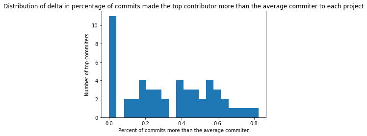

```python
delta_percent = []
for project in commit_map:
    max_count = 0
    total_count = 0
    for author in commit_map[project]:
        if commit_map[project][author] > max_count:
            max_count = commit_map[project][author]
        total_count += commit_map[project][author]
    top = max_count / total_count
    average = 1 / len(commit_map[project].keys())
    delta_percent.append(top - average)

plt.hist(delta_percent, 20)
plt.gca().set_xlabel('Percent of commits more than the average commiter')
plt.gca().set_ylabel('Number of top commiters')
plt.title('Distribution of delta in percentage of commits made the top contributor more than the average commiter to each project')

series = pd.Series(delta_percent)
print("Five number summary for delta percents")
print(series.describe())
```

##### 4.D Author Longevity

```python
def parse_date(date_string):
    # parse is imported from date_util
    # wrapper function makes naming more clear
    return parse(date_string)

# first a computation of author longevity is needed
# this can be done on a per project basis where within a project
# for each author the first and last date is tracked and then
# a timedelta can be computed between them
time_map = {}
for tuple in frame.itertuples():
    if tuple.project not in time_map:
        time_map[tuple.project] = {}
    if tuple.author not in time_map[tuple.project]:
        time_map[tuple.project][tuple.author] = {
            'min': parse_date(tuple.time),
            'max': parse_date(tuple.time),
            'count': commit_map[tuple.project][tuple.author]
        }
    else:
        date = parse_date(tuple.time)
        if date < time_map[tuple.project][tuple.author]['min']:
            time_map[tuple.project][tuple.author]['min'] = date
        if date > time_map[tuple.project][tuple.author]['max']:
            time_map[tuple.project][tuple.author]['max'] = date
```

```
Text(0.5,1,'Distribution of length of time over which contributors commited to modding projects')
```

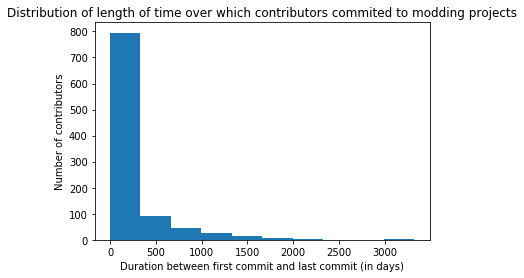

```python
deltas = []
for project in time_map:
    for author in time_map[project]:
        deltas.append((time_map[project][author]['max'] -
                      time_map[project][author]['min']).days)

plt.hist(deltas)
plt.gca().set_xlabel('Duration between first commit and last commit (in days)')
plt.gca().set_ylabel('Number of contributors')
plt.title('Distribution of length of time over which contributors commited to modding projects')
```

For the purposes of this analysis of the longevity of an author has been defined as the length of time between the first contribution they made to a project and the last contribution they made to that project. The above graph shows a histogram of author longevity across all of the video game modding projects in the sample. The distribution is clearly right skewed with a huge number of contributors falling into the bucket of having less than a year's duration as a contributor to a modding project. The number of authors that have worked on a project for a period of over a year is much much smaller in comparison.

```python
less_than_1_year = 0
at_least_1_year = 0
only_1_day = 0
for delta in deltas:
    if delta < 365:
        less_than_1_year += 1
    else:
        at_least_1_year += 1
    if delta == 0:
        only_1_day += 1

print('number with less than 1 year = ' + str(less_than_1_year))
print('percent with less than 1 year = ' + str(less_than_1_year / len(deltas)))
print('number with greater than 1 year = ' + str(at_least_1_year))
print('number with 1 day = ' + str(only_1_day))
print('percent with 1 day = ' + str(only_1_day / len(deltas)))
print('percent of less than 1 year that are 1 day = ' + str(only_1_day / less_than_1_year))
```

```
number with less than 1 year = 815
percent with less than 1 year = 0.8265720081135902
number with greater than 1 year = 171
number with 1 day = 380
percent with 1 day = 0.385395537525355
percent of less than 1 year that are 1 day = 0.4662576687116564
```

From the small bit of code above, over 80% of contributors to these video game modding projects have less than a year's duration as a contributor to the projects.

Another very interesting statistic is that many contributors only made contributions over the span of a single day (seen in the dataset as having a delta of 0) meaning that those contributors only contributed one commit in total to the project (or a few commits but all at once). This group of contributors makes up 38.6% of all contributors to open source modding projects.

How can these single contributions be explained? They certainly aren't by contributors that intended to be invested in the project and do long term work on it. Instead these contributors could possibly be programmers playing with the video game with the mod installed that found a bug or something that they personally wanted to change that they then contributed to the project. This certainly isn't the only plausible explanation but nonetheless this is a very interesting result.

As a follow up to seeing such a large percentage of contributors only contributing once to a project, a next step is an investigation into what percentage of the total commits to projects have been made by these contributors. Given that this almost 40% of contributors have made very few commits each it seems likely that they will have a much much smaller percentage of total commits than the 40% of contributors that they make up.

```python
authors_with_0 = []
for project in time_map:
    for author in time_map[project]:
        if (time_map[project][author]['max'] -
                      time_map[project][author]['min']).days == 0:
            authors_with_0.append(author)

commits_for_0 = 0
all_commit_count = 0

for project in commit_map:
    for author in commit_map[project]:
        if author in authors_with_0:
            commits_for_0 += commit_map[project][author]
        all_commit_count += commit_map[project][author]

print('commits for authors with 0 day length is = ' + str(commits_for_0))
print('all commits made is = ' + str(all_commit_count))
print('percentage of commits made by authors with 0 day length is = ' +
     str(commits_for_0 / all_commit_count))
```

```
commits for authors with 0 day length is = 767
all commits made is = 42972
percentage of commits made by authors with 0 day length is = 0.0178488317974495
```

And the numbers line up with the expectation. The commits made by these contributors that only have a contribution length of 0 only make up an incredibly small 1.8% of the total commits to the open source video game mods in the sample. This seems to indicate that the contributors that only contribute once to a project, although numerous, are not the main driving factor for development for video game mods. It seems that they are a nice to have for a project given that all development work helps, but certainly not a necessity given that these contributors make up such a small amount of commits to the projects.

Another interesting aspect of longevity to look at is how well does it correlate with the number of contributions made by an author. At first glance it seems clear that authors with longer longevity will make more contributions but this may not be entirely accurate. It is possible that there may be authors that make many many contributions to a project in a short time span or authors that come back to a project every once-in-a-while making very few commits but having a large longevity.

```
Text(0.5,1,'Relationship between the length of time an author contributes to a project and the number of contributions made')
```

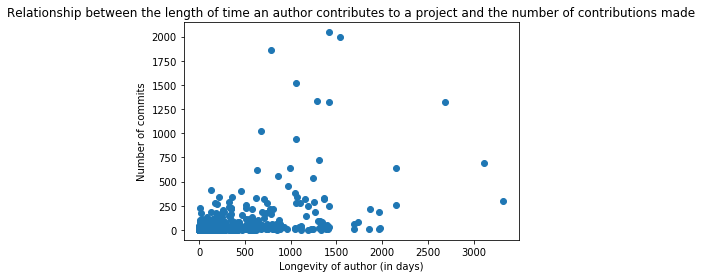

```python
author_longevity = []
author_commits = []

for project in time_map:
    for author in time_map[project]:
        author_longevity.append((time_map[project][author]['max'] -
                      time_map[project][author]['min']).days)
        author_commits.append(time_map[project][author]['count'])

plt.scatter(author_longevity, author_commits)
plt.gca().set_xlabel('Longevity of author (in days)')
plt.gca().set_ylabel('Number of commits')
plt.title('Relationship between the length of time an author contributes to a project and the number of contributions made')
```

The graph above is not as clear as it could be. The data towards the bottom left of the graph is far too clustered and close together to be able to read. Plotting both axes as log scales will make the graph easier to understand.

```
Text(0.5,1,'Relationship between the length of time an author contributes to a project and the number of contributions made')
```

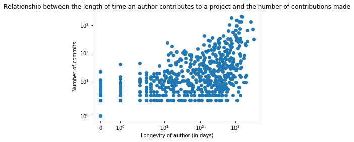

```python
plt.scatter(author_longevity, author_commits)
plt.yscale('symlog')
plt.xscale('symlog')
plt.gca().set_xlabel('Longevity of author (in days)')
plt.gca().set_ylabel('Number of commits')
plt.title('Relationship between the length of time an author contributes to a project and the number of contributions made')
```

After log transforming the x and y coordinates of the data, the graph becomes much easier to read. Some interesting properties that are made evident by this graph:

1. There exist data points for which the number of commits is 2 for authors with longevity values all across the log scale. This means that it is going to be impossible to create a regression model that accurately predicts all the data points because some points will have to be far from the prediction no matter the regression model that is found.
2. However there is one property of the graph that does seem like a predictable value: the maximum number of commits found for some author longevity seems to increase as the author longevity increases. So although predicting the actual number of commits for some author longevity may not be possible it seems feasible to predict the maximum potential number of commits fairly accurately. Though this does not seem like a particularly useful predictor given that if the longevity of the author is known, the exact number of commits made by that author also would be known and additionally trying to predict the maximum number of commits made by some author by some future date would not be useful because the maximum number of commits made isn't really useful information.

### 5. Conclusion

In this analysis article, the open source video game modding community was examined with the goal of better understanding how projects are structured. From this investigation there are three take-aways about the modding communnity.

1. Larger projects with more commits have more authors and vice-versa. There is no way to establish a causal relationship because this correlation could truly go either way but the data clearly establishes this positive correlation. More interestingly it seems that for each author in a project, the number of commits in a project increases by ~30 commits on average. What this means for the modding community is that to grow a project attempting to recruit new developers to work on the modding project is a very effective way to get more work done on a modding project.
2. The distribution of contribution count by author is very right skewed within the open source modding communnity. This means that most mods have many people that make a very small number of contributions with a small core group of developers that make the majority of the contributions to the project. This can be made more rigorous by looking a the percentage of total contributions made by the top contributor to the project versus the average. A two sample KS test confirmed that these distributions were statistically different with the top contributors definitely making significantly more contributions to the project than the average contributor. To put numbers to this difference, the top contributor made on average 30% more of the total contributions to the project than the average contributor. Note that this means that if there were 10 authors for a project, then this result predicts that the top contributor would have made 1/10=10% + 30% = 40% of the contributions to the project. These numbers really help to confirm the visual conclusion from earlier that mods have a small core group of developers that perform the majority of contributions to a project. What this means for the modding community is that development of mods really does focus around a small group of developers for each project that take the lead with the effort. This means that the modding community needs to be very aware that if the one or two top developers of some modding project decide that they no longer are enjoying that mod's development or maintenance anymore the project seems likely to die. Losing these core members would dramatically decrease the development work done on the project according to the data analysis done above.
3. Finally there isn't an effective way to predict how many contributions an individual developer will make to a project or how long a developer will work on a project. This means that the modding community does not have an effective way of determining how long the lifespan of a mod may be or how much work will be done on a mod. The relationship between longevity and contributions is just too unclear on a per author basis to try to make a predictive model.

Hopefully these insights will better help the modding community to understand how video game modding projects are structured and how they grow and shrink.